# Solucionario: PL3

Curso: POL304 - Estadística para el análisis político 2

Jefes de práctica: Alexander Benites, Chiara Zamora y Airám Bello

Ciclo 2023-2

Cargamos los datos:

```r
library(summarytools)
library(kableExtra)
library(rio)
library(magrittr)
library(margins)
```

```r
data = import("https://github.com/Alexanderbenit7/EAP2_2023-2/raw/main/data/data_2021_voting_final.xlsx")

#Formato:
data$PRIOR = factor(data$PRIOR, levels = c(0,1), labels = c("NoPriorizado","Priorizado"))
data$PC_VICT = factor(data$PC_VICT, levels = c(0,1), labels = c("No","Yes"))

str(data)
```

```
## 'data.frame':    1822 obs. of  16 variables:
##  $ UBIGEO          : chr  "010101" "010102" "010103" "010104" ...
##  $ DEPARTAMENTO    : chr  "AMAZONAS" "AMAZONAS" "AMAZONAS" "AMAZONAS" ...
##  $ PROVINCIA       : chr  "CHACHAPOYAS" "CHACHAPOYAS" "CHACHAPOYAS" "CHACHAPOYAS" ...
##  $ DISTRITO        : chr  "CHACHAPOYAS" "ASUNCION" "BALSAS" "CHETO" ...
##  $ ESTIM_POB       : num  29041 291 1639 595 716 ...
##  $ IDH_2019        : num  0.642 0.423 0.315 0.346 0.275 ...
##  $ %POBREZA        : num  0.0903 0.3652 0.4573 0.3917 0.5305 ...
##  $ %POBREZAEXT     : num  0.0144 0.1568 0.1543 0.2368 0.364 ...
##  $ TASA_NOLEER     : num  0.0849 0.1756 0.1673 0.095 0.1778 ...
##  $ TASA_INDIGENA   : num  0.05536 0.29771 0.0044 0.02181 0.00171 ...
##  $ TASA_NOAFILSALUD: num  0.1815 0.0458 0.1822 0.1106 0.053 ...
##  $ TASA_MAS80      : num  0.0198 0.0378 0.0134 0.0487 0.0335 ...
##  $ VALIDOS_PL      : num  55.6 79.6 58.7 69.7 46.5 ...
##  $ VALIDOS_FP      : num  44.4 20.4 41.3 30.3 53.5 ...
##  $ PRIOR           : Factor w/ 2 levels "NoPriorizado",..: 1 2 1 2 2 2 2 1 1 1 ...
##  $ PC_VICT         : Factor w/ 2 levels "No","Yes": 2 2 2 2 1 1 2 2 2 2 ...
```

### 1. Pregunta 1. Responda a lo siguiente:

1.1. ¿Cual es la probabilidad de que Pedro Castillo haya ganado en un distrito priorizado (con una tasa de personas mayores a 80 años por encima del promedio)

1.2. ¿Cuál es el valor del odds (De que sea priorizado/De que NO sea priorizado)

PC_VICT: Distrito en el que ganó Pedro Castillo PRIOR: Distrito con una tasa de personas mayores a 80 años por encima del promedio global

```r
dep=data$PC_VICT # a la fila
ind=data$PRIOR # a la columna

dataPRIORTable=table(dep,ind,dnn = c('PC','PRIOR'))

### suma por columna
addmargins(dataPRIORTable,margin = 1)%>%
    kable(caption = "Tabla de Contingencia: 'Priorizado' y 'Victoria PC'")%>%
    kableExtra::kable_styling(full_width = F)
```

Tabla de Contingencia: ‘Priorizado’ y ‘Victoria PC’

|  | NoPriorizado | Priorizado |
| --- | --- | --- |
| No | 246 | 125 |
| Yes | 885 | 565 |
| Sum | 1131 | 690 |

```r
#Valor de probabilidad:
ProbPC_Prior=dataPRIORTable[2,2]/sum(dataPRIORTable[,2])
MASS::fractions(ProbPC_Prior)
```

```
## [1] 113/138
```

```r
ProbPC_Prior
```

```
## [1] 0.8188406
```

```r
#Valor del ODDS:

ODDSPC_Prior=dataPRIORTable[2,2]/dataPRIORTable[1,2]
MASS::fractions(ODDSPC_Prior)
```

```
## [1] 113/25
```

```r
ODDSPC_Prior
```

```
## [1] 4.52
```

*Respuesta: 0.819 y 4.52*

### 2. Pregunta 2. Construya un modelo que responda a la siguiente hipotesis:

H: La victoria de Castillo en los distritos se explica por la tasa de personas que se identifican como indígenas (TASA_INDIGENA), la tasa de personas que no saben leer ni escribir (TASA_NOLEER) y si el distrito es uno priorizado (PRIOR).

```r
### No se olviden de declara la semilla
set.seed(2023)

### first hypothesis
h3=formula(PC_VICT ~ PRIOR + TASA_INDIGENA + TASA_NOLEER)

#regression
rlog3=glm(h3, data=data,family = binomial)

#results
summary(rlog3)
```

```
##
## Call:
## glm(formula = h3, family = binomial, data = data)
##
## Deviance Residuals:
##     Min       1Q   Median       3Q      Max
## -3.4392   0.0832   0.2453   0.6885   1.5399
##
## Coefficients:
##                 Estimate Std. Error z value Pr(>|z|)
## (Intercept)      -2.0954     0.2192  -9.559  < 2e-16 ***
## PRIORPriorizado   0.4401     0.1424   3.091  0.00199 **
## TASA_INDIGENA     4.3899     0.4054  10.829  < 2e-16 ***
## TASA_NOLEER      17.8579     1.5435  11.570  < 2e-16 ***
## ---
## Signif. codes:  0 '***' 0.001 '**' 0.01 '*' 0.05 '.' 0.1 ' ' 1
##
## (Dispersion parameter for binomial family taken to be 1)
##
##     Null deviance: 1841.2  on 1820  degrees of freedom
## Residual deviance: 1363.9  on 1817  degrees of freedom
##   (1 observation deleted due to missingness)
## AIC: 1371.9
##
## Number of Fisher Scoring iterations: 6
```

*Respuesta: Todas las variables son estadísticamente significativas y con un sentido positivo.*

### 3. Pregunta 3. ¿Cual es el impacto promedio de la variable TASA_INDIGENA en la probabilidad de que Pedro Castillo gane en un distrito?

```r
marginalsData=summary(margins(rlog3))
marginalsData%>% kable(caption = "Efectos Marginales Promedio (AME)- Modelo III") %>%kableExtra::kable_styling(full_width = T)
```

Efectos Marginales Promedio (AME)- Modelo III

| factor | AME | SE | z | p | lower | upper |
| --- | --- | --- | --- | --- | --- | --- |
| PRIORPriorizado | 0.0528137 | 0.0165813 | 3.185131 | 0.0014469 | 0.0203149 | 0.0853125 |
| TASA_INDIGENA | 0.5382030 | 0.0449903 | 11.962642 | 0.0000000 | 0.4500236 | 0.6263824 |
| TASA_NOLEER | 2.1893716 | 0.1584750 | 13.815245 | 0.0000000 | 1.8787662 | 2.4999770 |

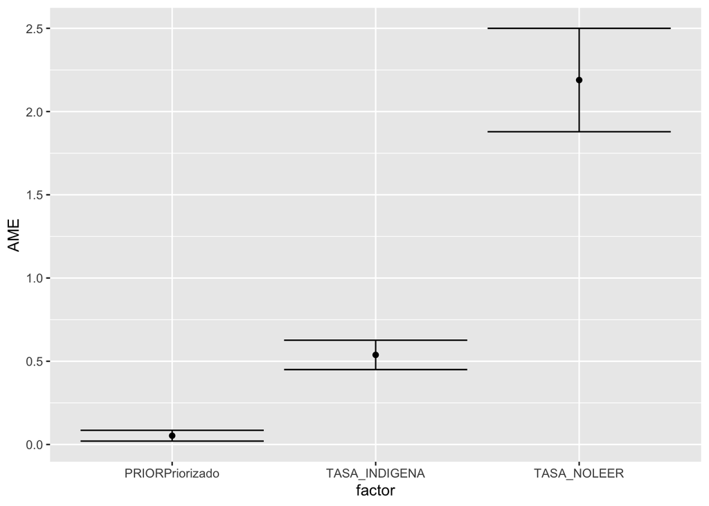

```r
library(ggplot2)
base= ggplot(marginalsData,aes(x=factor, y=AME)) + geom_point()
base +  geom_errorbar(aes(ymin=lower, ymax=upper))
```

*Respuesta: El aumento de un punto en la variable TASA_INDIGENA aumenta la probabilidad en 0.538*